# Description

This case requires developing a customer segmentation to define a marketing strategy. The sample Dataset summarizes the usage behavior of about 9000 active credit cardholders during the last 6 months. The file is at a customer level with 18 behavioral variables.

Following is the Data Dictionary for Credit Card dataset:

- CUSTID: Identification of Credit Cardholder (Categorical)
- BALANCE: Balance amount left in their account to make purchases
- BALANCEFREQUENCY: How frequently the Balance is updated, score between 0 and 1 (1 = frequently updated, 0 = not frequently updated)
- PURCHASES: Amount of purchases made from the account
- ONEOFFPURCHASES: Maximum purchase amount did in one-go
- INSTALLMENTSPURCHASES: Amount of purchase done in installment
- CASH ADVANCE: Cash in advance given by the user
- PURCHASESFREQUENCY: How frequently the Purchases are being made score between 0 and 1 (1 = frequently purchased, 0 = not frequently purchased)
- ONEOFFPURCHASESFREQUENCY: How frequently Purchases are happening in one go (1 = frequently purchased, 0 = not frequently purchased)
- PURCHASESINSTALLMENTSFREQUENCY: How frequently purchases in installments are being done (1 = frequently done, 0 = not frequently done)
- CASHADVANCEFREQUENCY: How frequently is the cash in advance being paid
- CASHADVANCETRX: Number of Transactions made with "Cash in Advanced"
- PURCHASESTRX: Number of purchase transactions made
- CREDIT LIMIT: Limit of Credit Card for user
- PAYMENTS: Amount of Payment done by the user
- MINIMUM_PAYMENTS: Minimum amount of payments made by the user
- PRCFULLPAYMENT: Percent of full payment paid by the user
- TENURE: Tenure of credit card service for user

```python
import numpy as np # linear algebra
import pandas as pd # data processing, CSV file I/O (e.g. pd.read_csv)
import matplotlib.pyplot as plt
import seaborn as sns
import warnings
warnings.filterwarnings(action="ignore")

import os
```

```python
data= pd.read_csv('/kaggle/input/ccdata/CC GENERAL.csv')
data
```

```python
data.info()
```

```python
data.describe().T
```

```python
data.isnull().sum().sort_values(ascending=False)
```

```python
cat_cols = data.select_dtypes(include=['object']).columns
num_cols = data.select_dtypes(exclude=['object']).columns
```

```python
cat_cols
```

```python
num_cols
```

```python
data['myid'] =data['CUST_ID'].str[0]
```

```python
data['myid'].unique()
```

```python
df_v=pd.DataFrame(data['TENURE'].value_counts())
df_v
```

```python
colors = sns.color_palette('pastel')

#create pie chart
plt.figure(figsize=(10,10))
plt.pie(df_v['TENURE'], labels = df_v.index, colors = colors, autopct='%.0f%%')
plt.show()
```

```python
df_v=pd.DataFrame(data['TENURE'].value_counts())
colors = sns.color_palette('pastel')[0:5]
plot = df_v.plot.pie(y='TENURE', figsize=(8, 8),colors=colors);
```

```python
sns.boxplot(x = 'TENURE', y = 'CREDIT_LIMIT', data = data,palette='Pastel1');
```

```python
sns.boxplot(x = 'TENURE', y = 'BALANCE_FREQUENCY', data = data,palette='autumn');
```

```python
sns.scatterplot(x='CREDIT_LIMIT', y='PRC_FULL_PAYMENT', data=data,color='purple');
```

```python
sns.scatterplot(x='BALANCE', y='PURCHASES', data=data,color='purple');
```

```python
data[num_cols].hist(bins=15, figsize=(20, 15), layout=(5, 4));
```

```python
data[num_cols].corr()
```

```python
plt.subplots(figsize=(20,15))
sns.heatmap(data[num_cols].corr(),annot = True);
```

## Filling in missing data with KnnImputer

```python
import missingno as msno
plt.figure(figsize=(10,10))
msno.matrix(data)
```

```python
from sklearn.impute import KNNImputer
imputer = KNNImputer()
imp_data = pd.DataFrame(imputer.fit_transform(data[num_cols]),columns=data[num_cols].columns)
imp_data.isna().sum()
```

```python
imp_data
```

# Clustering with PyCaret

```python
!pip install pycaret
```

```python
from pycaret.clustering import *
```

```python
clu = setup(imp_data, normalize = True,
            pca = True,silent =True,
            combine_rare_levels= True,
            remove_multicollinearity= True,
            session_id = 69)
```

```python
models()
```

## KMeans

K-means is one of the most commonly used clustering algorithms. It can cluster large-scale data quickly and effectively. “K” refers to the fixed number of clusters needed before starting the algorithm.

The K-means clustering method divides a dataset consisting of N data objects into K clusters given as input parameters. The aim is to ensure that the clusters obtained at the end of the partitioning process have maximum similarities within clusters and minimum similarities between clusters.

```python
kmeans = create_model('kmeans')
```

```python
kmean_results = assign_model(kmeans)
kmean_results.head()
```

```python
plot_model(kmeans)
```

```python
plot_model(kmeans, plot = 'elbow')
```

```python
plot_model(kmeans, plot = 'silhouette')
```

```python
plot_model(kmeans, plot = 'distribution') #to see size of clusters
```

```python
plot_model(kmeans, plot = 'distribution', feature = 'TENURE')
```

```python
plot_model(kmeans, plot = 'distribution', feature = 'PAYMENTS')
```

```python
plot_model(kmeans, plot ='distance')
```

```python
plot_model(kmeans, plot ='tsne')
```

## Hierarchical Clustering

Hierarchical clustering is a method of cluster analysis that attempts to create a hierarchy of clusters. Hierarchical clustering strategies are generally divided into two types:

1. **Agglomerative**: This is a "bottom-up" approach: each observation starts in its own cluster, and pairs of clusters are merged as one moves up the hierarchy.
2. **Divisive**: This is a "top-down" approach: all observations start in one cluster, and splits are performed recursively as one moves down the hierarchy.

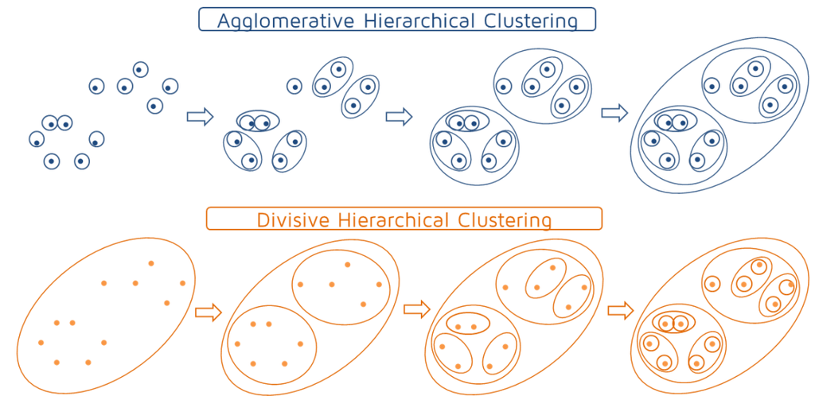

```python
hierarchical_clust = create_model('hclust')
```

```python
hierarchical_results = assign_model(hierarchical_clust)
hierarchical_results.head()
```

```python
plot_model(hierarchical_clust)
```

```python
plot_model(hierarchical_clust, plot = 'distribution') #to see size of clusters
```

```python
plot_model(hierarchical_clust, plot ='tsne')
```